# Análise de Regressão

```r
Y = as.numeric(`TOTAL FEED (ton/h) PV`)
```

```
NAs introduzidos por coerção
```

```r
X = as.numeric(`TOTAL FEED (ton/h) SP`)
```

```
NAs introduzidos por coerção
```

```r
dados <- data.frame(Y,X)
```

```r
modelo.regressao <- lm(Y ~ X, data= dados)
summary(modelo.regressao)
```

```
Call:
lm(formula = Y ~ X, data = dados)

Residuals:
    Min      1Q  Median      3Q     Max
-92.921   5.441   6.880   7.587  31.515

Coefficients:
            Estimate Std. Error t value Pr(>|t|)
(Intercept) -9.62361    0.73830  -13.04   <2e-16 ***
X            1.03165    0.01137   90.70   <2e-16 ***
---
Signif. codes:  0 ‘***’ 0.001 ‘**’ 0.01 ‘*’ 0.05 ‘.’ 0.1 ‘ ’ 1

Residual standard error: 19.66 on 49752 degrees of freedom
  (14 observations deleted due to missingness)
Multiple R-squared:  0.1419,    Adjusted R-squared:  0.1419
F-statistic:  8227 on 1 and 49752 DF,  p-value: < 2.2e-16
```

```r
anova(modelo.regressao)
```

```
Analysis of Variance Table

Response: Y
             Df   Sum Sq Mean Sq F value    Pr(>F)
X             1  3179847 3179847  8227.5 < 2.2e-16 ***
Residuals 49752 19228692     386
---
Signif. codes:  0 ‘***’ 0.001 ‘**’ 0.01 ‘*’ 0.05 ‘.’ 0.1 ‘ ’ 1
```

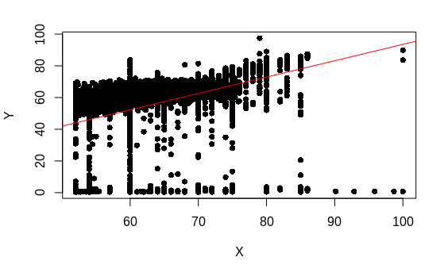

```r
plot (Y ~ X,pch=16 ,data = dados)
abline(modelo.regressao,col="red")
```

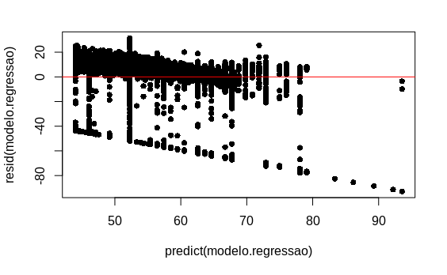

```r
plot(resid(modelo.regressao) ~ predict(modelo.regressao),pch=16) # Resíduos vs. Y esperado
abline(0,0,col="red")
```

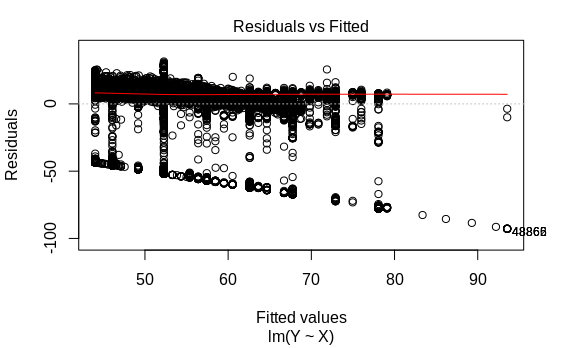

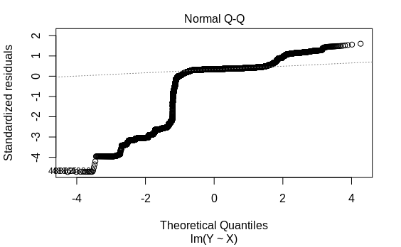

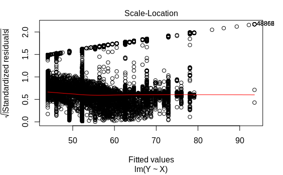

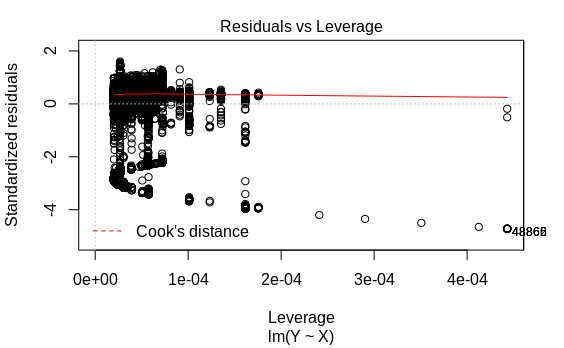

```r
plot(modelo.regressao)
```

Modelos de Regressão são utilizados para descrever o relacionamento de uma variável $y$ com outra (ou outras) variável $x$, por meio de uma relação matemática da forma
$$y = f(x;\hbox{$\boldsymbol \beta$}) + \textrm{erro}.$$
Quando a função $f$ é do tipo
$$f(x;\hbox{$\boldsymbol \beta$}) = \beta_0 + \beta_1 x,$$
$\hbox{$\boldsymbol \beta$}=(\beta_0,\beta_1) \in \mathbb{R}^2$, tem-se um modelo de regressão linear simples. A variável $x$ é a variável independente do modelo, enquanto $y$ depende das variações de $x$, e é chamada de variável resposta. Assim, o modelo de regressão é chamado de simples quando envolve uma relação causal entre duas variáveis, $x$ e $y$. O modelo de regressão é múltiplo quando envolve uma relação causal entre mais de duas variáveis. Ou seja, quando a variação da resposta $y$ pode ser explicada por mais de uma variável independente, $x_1,...,x_p$, que são também denominadas variáveis explicativas ou covariáveis.

Modelos de regressão podem ser aplicados em vários tipos de probelas.

1 - Em problemas em que se deseja realizar previsões sobre o comportamento futuro de algum fenômeno, extrapolando-se para o futuro as relações de causa e efeito observados no passado.

2 - Quando é desejado observar efeitos causados por uma variável $x$ sobre outra variável (sobre a variável resposta) em decorrência de alterações introduzidas em seus valores.

**Modelos de Regressão Linear Simples**

A covariância e o coeficiente de correlção será necessária para saber se existe uma relação linear entre os dados, para poder ultilizar o método da reta de regressão. Se a covariância for negativa significa que os dados tem uma tendência decrescente, caso contrário a tendência será crescente e se a covariância for zero, não existe nenhuma tendência linear.

A fórmula abaixo é utilizada para calcular a covariância amostral.

$$s_{xy}=\frac {\sum^{n}_{i=1}x_i\cdot y_i - \frac{(\sum^{n}_{i=1}x_i)(\sum^{n}_{i=1}y_i)}{n}}{n-1}$$

O coeficiente de correlção é expresso pelo seguinte fórmula. Onde $s_x$ e $s_y$ são os desvios padrões e o valor de $r$ está entre 1 e -1, quanto mais próximo de 1 ou -1, mais linear é a relação entre as variáveis x e y. Se $r$ for positivo quando uma variável cresce a outra também irá crescer, e se for negativo quando uma cresce a outra diminui e se for 0 significa que x e y não tem correlção linear.

$$r_{xy}=\frac{s_{xy}}{s_x\cdot s_y}$$

Com a finalidade de mostrar a função da reta que melhor decreve os dados deve-se fazer a aproximação dos betas, que seguem as seguintes funções:
$$\hat{\beta_0} = \frac{n \cdot \sum x_iy_i-\sum x_i \cdot \sum y_i}{n \cdot \sum x_i^2 -( \sum x_i)^2}$$
$$\hat{\beta_1} = \overline{y}-\hat{\beta_0}\cdot\overline{x}$$
Para aproximação do $\beta_1$ será necessário o valor das medias amostrais, que serão expressa pelas seguintes fórmulas:
$$\overline{x} = \frac{\sum x_i}{n}$$

$$\overline{y} = \frac{\sum y_i}{n}$$
Essa aproximção também pode ser calculada através da covariância seguindo as fórmulas:
$$\hat{\beta_1} = \frac{s_{xy}}{s_x^2}$$
$$\hat{\beta_0} = \frac{\sum^{n}_{i=1}y_i-\hat{\beta_1}\cdot \sum^{n}_{i=1}x_i}{n}$$
**Modelos de Regressão Linear Múltiplo**

O modelo de regressão linear múltiplo é expresso pela função linear:
$$y = \beta_0 + \beta_1 x_1 + ... + \beta_p x_p + \varepsilon$$
em que:

$y$ é a variável resposta (variável dependente no modelo)

$x_1,...,x_p$ são as covariáveis (variáveis independentes ou explicativas), supostamente independentes entre si;

$\beta_0,...,\beta_p$ são os coeficientes da regressão;

$\varepsilon$ é o erro aleatório.

Agora, considere uma amostra $y_1,...,y_n$ de $y$ em que cada $y_i$ está associado às $p$ variáveis explicativas, $x_i,x_{i1},...,x_{ip}$, $i=1,..,n$, assim pelo modelo
$$y_i = \beta_0 + \beta_1x_{i1} + ... + \beta_px_{ip} + \varepsilon_i\,,$$
$i=1,..,n$ e $n>p$, que pode ser visto como um modelo de regressão linear amostral.

No modelo de regressão usual, os $\varepsilon_i$’s são variáveis aleatórias sujeitas as seguintes condições:

- $E[\varepsilon_i] = 0$;
  - $Var(\varepsilon_i) = \sigma^2$;
  - $Cov(\varepsilon_i,\varepsilon_j) = 0 \,, \forall i \neq j\,, j=1,...,n$.

Note que, $x_{i1},...,x_{ip}$ são variáveis numéricas, não são variáveis aleatórias. No entanto, cada $y_i$ depende da quantidade aleatória $\varepsilon_i$ e portanto é uma variável aleatória. Assim, a média de $y_i$ é dada por:
$$E[y_i] = E[\beta_0 + \beta_1x_{i1} + ... + \beta_px_{ip} + \varepsilon_i] = \beta_0 + \beta_1x_{i1} + ... + \beta_px_{ip}$$
e a variância é dada por:
$$Var(y_i) = Var(\beta_0 + \beta_1x_{i1} + ... + \beta_px_{ip} + \varepsilon_i) = \sigma^2, \ \ \ \forall i .$$

Usando a notação matricial, o modelo é dado por:

$$\begin{pmatrix}
y_1 \\ y_2 \\ \vdots \\ y_n
\end{pmatrix}
=
\begin{pmatrix}
1 & x_{11} & x_{12} & \cdots & x_{1p} \\
1 & x_{11} & x_{12} & \cdots & x_{1p} \\
\vdots & \vdots & \vdots & \ddots & \vdots \\
1 & x_{n1} & x_{n2} & \cdots & x_{np} \\
\end{pmatrix}
\begin{pmatrix}
\beta_0 \\ \beta_1 \\ \vdots \\ \beta_p
\end{pmatrix}
+
\begin{pmatrix}
\varepsilon_1 \\ \varepsilon_2 \\ \vdots \\ \varepsilon_n
\end{pmatrix}
\Rightarrow
\textbf{Y}= X \beta+ \varepsilon$$

A matriz $X$ de dimensão $n \times (p+1)$ e chamada de matriz de regressão quando $rank[X] = p+1$, e é chamada de matriz de delineamento quando $rank[X] = r < p+1$. A coluna de $1$’s na matriz refere-se ao intercepto, $\beta_0$. O vetor $Y$ de dimensão $n \times 1$ contém as variáveis $y_1,..,y_n$, $\beta$ é o vetor de dimensão $(p+1) \times 1$ dos coeficientes de regressão e $\varepsilon$ é o vetor de erros aleatórios de dimensão $n \times 1$.

Conseqüentemente,
$$E[{ \bf Y}] = E[X{ \bf \beta}+{ \bf \varepsilon}]$$
e
$$Var({ \bf Y}) = Var(X{ \bf \beta}+{ \bf \varepsilon}) = \sigma^2 I_n\,,$$
em que $I_n$ é a matriz identidade de dimensão $n \times n$.

**Estimação por mínimos quadrados**

O método de mínimos quadrados ($MMQ$) aplica-se somente aos parâmetros ${ \bf \beta} = (\beta_0,\beta_1,...,\beta_p)$, e é frequentemente aplicado em situações em que não se dispõe de mais especificações, além das que já foram feitas, sobre os erros. Este método consiste em estimar $\widehat{{ \bf \beta}} = (\widehat{\beta_0},\widehat{\beta_1},...,\widehat{\beta_p})$ por ${ \bf \beta} = (\beta_0,\beta_1,...,\beta_p)$ de modo que o vetor de valor esperado $E[{ \bf Y}] = X{ \bf \beta}$ esteja tão perto quanto possível do vetor de observações ${ \bf y}$ de ${ \bf Y}$. Ou seja, os estimadores de mínimos quadrados de $\beta_0,\beta_1,...,\beta_p$ devem minimizar a soma dos quadrados dos erros, dada por:

$$U({ \bf \beta}) = \displaystyle\sum_{i=1}^n\varepsilon_i^2 = \displaystyle\sum_{i=1}^n(y - \beta_0 - \beta_1x_{i1} - ... - \beta_px_{ip})^2 =
{ \bf \varepsilon}^T{ \bf \varepsilon}$$

Nota que $U({ \bf \beta})$ pode ser expresso por:
$$U({ \bf \beta}) = { \bf Y}^T{ \bf Y} - { \bf \beta}^TX^T{ \bf Y} - { \bf Y}^TX{ \bf \beta} + { \bf \beta}^TX^TX{ \bf \beta} = { \bf Y}^T{ \bf Y} - 2{ \bf \beta}^TX^T{ \bf Y} + { \bf \beta}^TX^TX{ \bf \beta}$$

Derivando $U({ \bf \beta})$ com respeito a ${ \bf \beta}$ e igualando a zero, temos:
$$\dfrac{\partial U({ \bf \beta})}{\partial { \bf \beta}} = - 2X^T{ \bf Y} + 2X^TX\widehat{{ \bf \beta}} = 0 \,,$$
que resulta em:
$$X^TX{ \bf \beta} = X^T{ \bf Y} \,,$$
denominadas equações normais.

Se $rank[X] = p+1$, $X^TX$ é positiva definida e, portanto, inversível (não-singular). Assim, as equações normais possuem uma solução única dada por:
$$\widehat{{ \bf \beta}} = (X^TX)^{-1}X^T{ \bf Y} \,,$$
em que $\widehat{{ \bf \beta}}$ é o estimador de mínimos quadrados ($EMQ$) de $\beta$.

O modelo de regressão ajustado, correspondente ao vetor, ${ \bf Y}$, é dado por:
$$\widehat{{ \bf Y}} = X\widehat{{ \bf \beta}} = X(X^TX)^{-1}X^T{ \bf Y} = H{ \bf Y}\,.$$

A matriz $H = X(X^TX)^{-1}X^T$ de dimensão $n \times n$ é geralmente chamada de matriz chapéu. Essa matriz possui algumas propriedades importantes que são enunciadas no teorema a seguir.

Teorema $3.1$: Suponha que X é uma matriz $n \times (p+1)$ de $rank$ completo $p+1$. Então,

- $H$ e ($I_n - H$) são simétricas e idempotente;
- $rank[I_n - H] = Tr[I_n - H] = n-(p+1) = n-p-1$;
- $HX = X$.